# Data Wrangling Report

#### by: Mostafa Mohammad Bestawy Elnoby

#### March 2021

### This report explains some insights and relationships for Udacity Data professional Nanodegree Program, Project 2 "Wrangle and Analysis Data"

#### After wringling process .It's the time to extract insights supported by data visualization to help business and decision makers.

## 1.Retweet Count and Favorite Count Relationship

#### as excpected, a good tweet has more interactions.as illustrated in Fig.1 there is a positive relationship between retweet count and favorite count which represent users interactions with the tweet.

###### the realtion could be interpolated as a linear postive relation

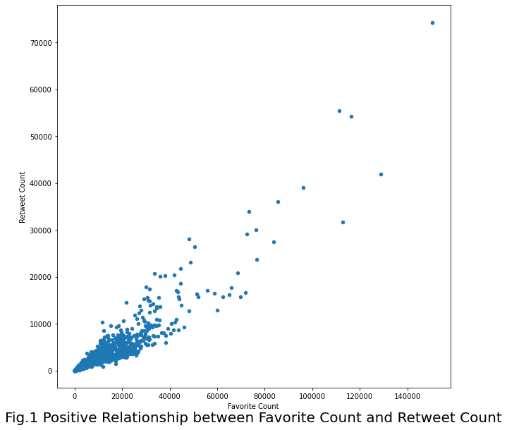

## 2.High Rating stages

### as illustared in Fig.2 doggo, puppo stage has the highest rating with average rating of 13,then

###### 2-puppo 12/10

###### 3-floofer 11.89/10,

###### 4-doggo 11/83,

###### 5-doggo, pupper 11.11/10,

###### 6-doggo, floofer 11/10

###### and lastly pupper 10.73/10.

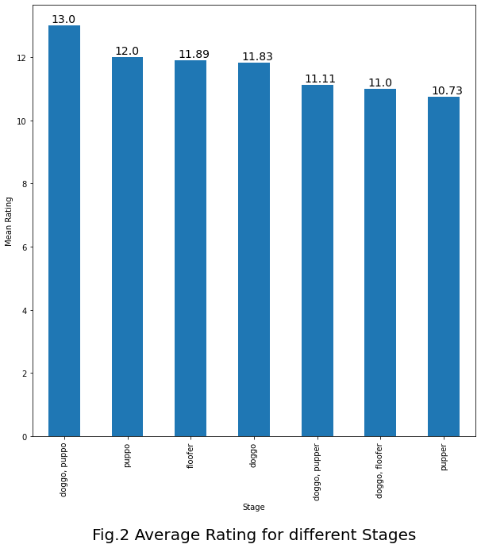

## 3.High Interactions Breeds

#### in terms of interaction we took mean retweet count as an indication

[figure not shown]

## 6.WeRateDogs trend

### as illustared in Fig.6 WeRateDogs have more interactions from users over time

###### again we represent users interaction by both retweet count and favorite count

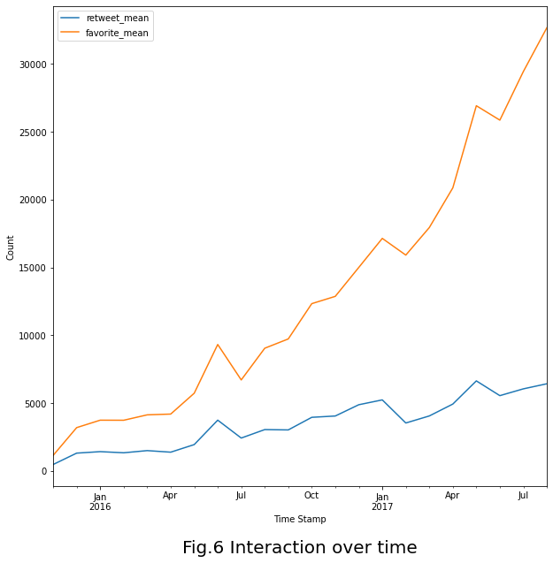

## 7.Best Names

### as illustared in Fig.7 let's suggest some best names to have higher ratings

###### copper, lucy, oliver, charlie,penny,tucker,winston,lola and sadie

[figure not shown]